# Act Report by Agbons Ekata-Inuaghata

### I am not a big fan of dogs but many people are so fond of dogs that they have numerous dogs as pets and suprisingly some few even went the extra mile of rating dogs on twitter which is quite fascinating

### A twitter account named WeRateDogs rates dogs over a standard denominator of 10 and the numerator is always above 10 because the owner of account considers all dogs as good dogs. This account has accumulated huge following on twitter and also international media coverage

### I have wrangled the data from the WeRateDogs twitter account to provide answers to insightful questions which include which dog breed is the most popular, which dog stage has the most retweets, and which dog breed has thenmostblikes. Python librabries helped me in coming up with visualizations in order to draw insights from my analysis

## Most Popular Dog Breeds

### I analysed the twitter data based on the first prediction column and these were the most popular dog breeds

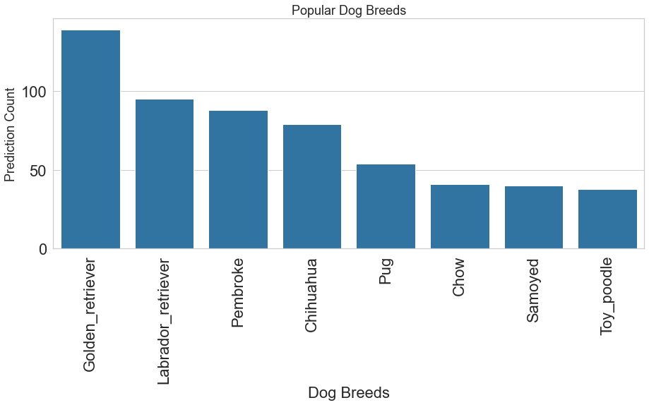

### This analysis gave me an insight on the data which is Golden Retriever being the most popular dog breed

## Most Popular Dog Stage by Retweet Count

[figure not shown]

```python
sb.set_style('whitegrid')
plt.figure(figsize = (15,6))
sb.barplot(data = frequency, x = frequency.stage, y = frequency.retweet_mean, color = base_color,
           order = frequency.sort_values('retweet_mean', ascending = False).stage);
plt.xticks(rotation=90);
sb.set(font_scale = 2);
plt.xlabel("Dog Stage",fontsize = 22);
plt.ylabel("Retweet Mean",fontsize = 18);
plt.title("Dog Stage and Retweets",fontsize = 18);
```

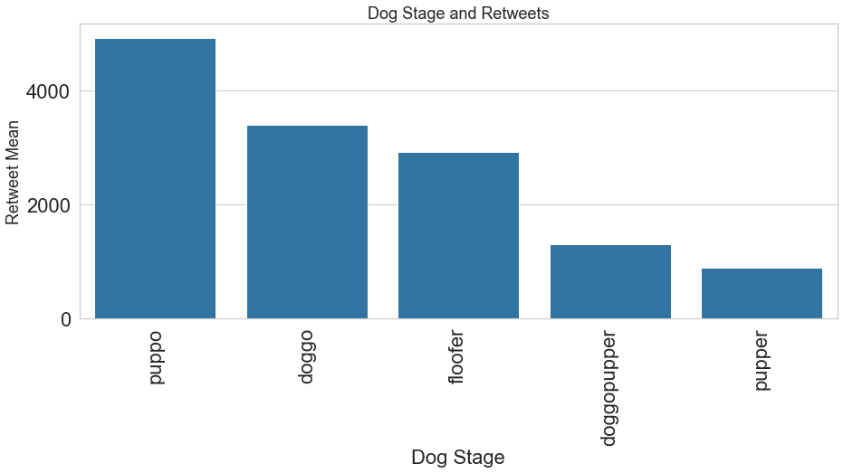

### This analysis gave me an insight on the data which puppo stage being the most popular by retweet count

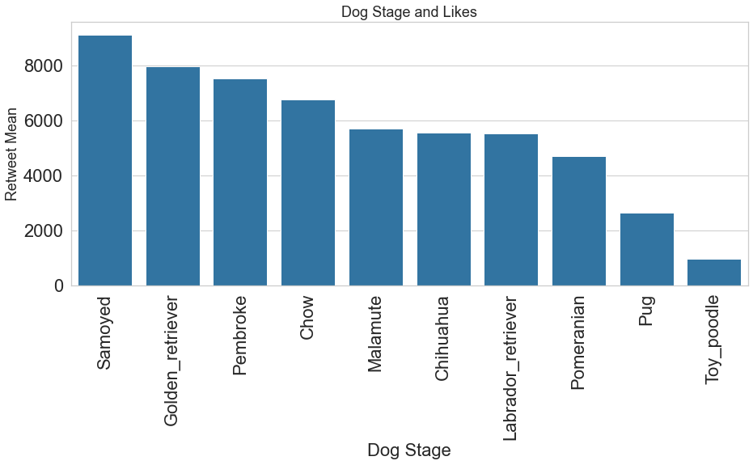